# GLMM Analysis for Circle Time

Pourya Shahverdi

2025-06-26

# About the Study

## Introduction to Circle-Time

Circle-time is a group activity based on Applied Behavior Analysis (ABA) for children with Autism Spectrum Disorder (ASD) to prepare them for attending in traditional classroom activities alongside neurotically developed children. In circle-time, children sit together semicircular, and an instructor give them group instruction activities such as dance, yoga, labeling animals, finding objects, etc. The goal of circle-time is to improve children’s learning behaviors, which are:

- Affect
- Communication
- Engagement
- Performance

In this study, we evaluate the efficacy of a social robot in delivering group instruction activities to children with ASD. Throughout the six month of experiment, Six children participants received 10 sessions of group instructions from a human instructor and 10 sessions from a Pepper humanoid social robot as a within-subject study design. To compare children learning behaviors between the human and the robot instructor conditions their activities were video recorded and coded for the sessions 1, 4, 7, and 10.

## Study Design

For this longitudinal within-subject study with 6 participants we defined the following variables:

#### Independent Variables

- Instructor Conditions:
  - Human ~ 1
  - Robot ~ 2
- Time
  - Session 1 ~ 1
  - Session 4 ~ 2
  - Session 7 ~ 3
  - Session 10 ~ 4

#### Dependent Variables

- Affect
- Communication
- Engagement
- Performance

### Data Collection

The evaluation of the learning behavior is based on the following continuous metrics:

#### Affect

children’s happiness level was defined as:

- Positive
- Negative
- Neutral

A video was divided into 10 seconds intervals, and a human coder, focusing on one child in the group, labeled that interval as Positive if the child was showing positive affective behaviors (e.g., smiling, Clapping, laughing). An interval was labeled as Negative if the target child was showing negative affective behaviors (e.g., crying, whining, frowning). And, and an interval was labeled as Neutral if it was neither Positive or Negative. Percentage of each measurement is used for analysis as a continuous variable.

#### Communication

Communication of the children was coded into 4 categories. Communication with:

- Instructor
- Instructor-Prompted
- Behavior Therapist (BT) or peers
- Indeterminate

#### Engagement

Engagement was coded into 3 categories. Engagement with:

- Instructor or screen (On Target)
- BT or peers
- Off Target

#### Performance

Children’s performance was coded into two categories:

- Positive
- Negative

#### Inter-observer Agreement (IoA)

At the beginning of the coding procedure, coders’ understanding of the metrics had to be on the same page. We used Cohen’s Kappa score to evaluate the IoA on the coding procedure. An individual coder was allowed to code independently only if their Cohen’s Kappa IioA score was higher than 80%. All session ones and tens were double coded as well as the 30% of the session fours and sevens. For the sessions with lower than 80% agreement, coders went through coding together and came up with 100% agreement. We considered this conservative approach since we were looking into the highest reliability of data on our 6 participants.

# Data Analysis

In order to investigate the research questions, we analyze the data from children’s learning behaviors as follows:

## Affect

### Positive Affect

```r
library(glmmTMB)
library(performance)
library(DHARMa)
df <- read.csv("~/GitHub/Circle-Time-Data-Analyses/CircleTimeData-VBMAPP.csv")

epsilon <- 0.0001
df$Affect_Positive <- (df$Affect_Positive * (nrow(df) - 1) + epsilon) / nrow(df)


model0 <- glmmTMB(
  Affect_Positive ~ Condition + time + (1 | Subject),
  data = df,
  family = beta_family()
)

summary(model0)
```

```
##  Family: beta  ( logit )
## Formula:          Affect_Positive ~ Condition + time + (1 | Subject)
## Data: df
##
##       AIC       BIC    logLik -2*log(L)  df.resid
##    -116.3    -107.0      63.2    -126.3        43
##
## Random effects:
##
## Conditional model:
##  Groups  Name        Variance Std.Dev.
##  Subject (Intercept) 0.1608   0.401
## Number of obs: 48, groups:  Subject, 6
##
## Dispersion parameter for beta family ():   29
##
## Conditional model:
##             Estimate Std. Error z value Pr(>|z|)
## (Intercept) -2.32108    0.33325  -6.965 3.29e-12 ***
## Condition    0.44614    0.15024   2.970  0.00298 **
## time        -0.07593    0.06560  -1.157  0.24707
## ---
## Signif. codes:  0 '***' 0.001 '**' 0.01 '*' 0.05 '.' 0.1 ' ' 1
```

```r
model <- glmmTMB(
  Affect_Positive ~ Condition + time + VBMAPP + (1 | Subject),
  data = df,
  family = beta_family()
)

summary(model)
```

```
##  Family: beta  ( logit )
## Formula:          Affect_Positive ~ Condition + time + VBMAPP + (1 | Subject)
## Data: df
##
##       AIC       BIC    logLik -2*log(L)  df.resid
##    -116.2    -104.9      64.1    -128.2        42
##
## Random effects:
##
## Conditional model:
##  Groups  Name        Variance Std.Dev.
##  Subject (Intercept) 0.1056   0.325
## Number of obs: 48, groups:  Subject, 6
##
## Dispersion parameter for beta family (): 28.8
##
## Conditional model:
##             Estimate Std. Error z value Pr(>|z|)
## (Intercept)  1.98507    2.91381   0.681   0.4957
## Condition    0.43524    0.15082   2.886   0.0039 **
## time        -0.07760    0.06579  -1.179   0.2382
## VBMAPP      -2.66257    1.79291  -1.485   0.1375
## ---
## Signif. codes:  0 '***' 0.001 '**' 0.01 '*' 0.05 '.' 0.1 ' ' 1
```

```r
model_interaction <- glmmTMB(
  Affect_Positive ~ Condition * VBMAPP + Condition * time + (1 | Subject),
  data = df,
  family = beta_family()
)


summary(model_interaction)
```

```
##  Family: beta  ( logit )
## Formula:
## Affect_Positive ~ Condition * VBMAPP + Condition * time + (1 |      Subject)
## Data: df
##
##       AIC       BIC    logLik -2*log(L)  df.resid
##    -120.1    -105.2      68.1    -136.1        40
##
## Random effects:
##
## Conditional model:
##  Groups  Name        Variance Std.Dev.
##  Subject (Intercept) 0.1158   0.3404
## Number of obs: 48, groups:  Subject, 6
##
## Dispersion parameter for beta family (): 35.4
##
## Conditional model:
##                  Estimate Std. Error z value Pr(>|z|)
## (Intercept)      12.23529    4.70974   2.598  0.00938 **
## Condition        -6.10422    2.39120  -2.553  0.01069 *
## VBMAPP           -9.26994    2.91395  -3.181  0.00147 **
## time              0.02240    0.19762   0.113  0.90976
## Condition:VBMAPP  4.21557    1.47504   2.858  0.00426 **
## Condition:time   -0.06959    0.12115  -0.574  0.56570
## ---
## Signif. codes:  0 '***' 0.001 '**' 0.01 '*' 0.05 '.' 0.1 ' ' 1
```

```r
library(glmmTMB)
library(ggeffects)
library(ggplot2)

# Fit the interaction model
model <- glmmTMB(
  Affect_Positive ~ Condition * VBMAPP + Condition * time + (1 | Subject),
  data = df,
  family = beta_family()
)

# Get predicted values
pred <- ggpredict(model, terms = c("VBMAPP", "Condition"))  # marginal effects
```

```
## You are calculating adjusted predictions on the population-level (i.e.
##   `type = "fixed"`) for a *generalized* linear mixed model.
##   This may produce biased estimates due to Jensen's inequality. Consider
##   setting `bias_correction = TRUE` to correct for this bias.
##   See also the documentation of the `bias_correction` argument.
```

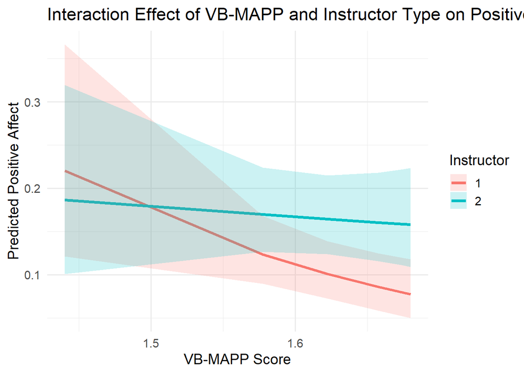

```r
# Plot
ggplot(pred, aes(x = x, y = predicted, color = group)) +
  geom_line(size = 1.3) +
  geom_ribbon(aes(ymin = conf.low, ymax = conf.high, fill = group), alpha = 0.2, color = NA) +
  labs(
    x = "VB-MAPP Score",
    y = "Predicted Positive Affect",
    color = "Instructor",
    fill = "Instructor",
    title = "Interaction Effect of VB-MAPP and Instructor Type on Positive Affect"
  ) +
  theme_minimal(base_size = 14)
```

### Negative Affect

```r
library(glmmTMB)
library(performance)
library(DHARMa)

df <- read.csv("~/GitHub/Circle-Time-Data-Analyses/CircleTimeData-VBMAPP.csv")

epsilon <- 0.0001
df$Affect_Negative <- (df$Affect_Negative * (nrow(df) - 1) + epsilon) / nrow(df)


model <- glmmTMB(
  Affect_Negative ~ Condition + time + VBMAPP + (1 | Subject),
  data = df,
  family = beta_family()
)

summary(model)
```

```
##  Family: beta  ( logit )
## Formula:          Affect_Negative ~ Condition + time + VBMAPP + (1 | Subject)
## Data: df
##
##       AIC       BIC    logLik -2*log(L)  df.resid
##    -658.2    -647.0     335.1    -670.2        42
##
## Random effects:
##
## Conditional model:
##  Groups  Name        Variance  Std.Dev.
##  Subject (Intercept) 4.046e-09 6.361e-05
## Number of obs: 48, groups:  Subject, 6
##
## Dispersion parameter for beta family (): 16.1
##
## Conditional model:
##             Estimate Std. Error z value Pr(>|z|)
## (Intercept)  -6.5531     2.7593  -2.375   0.0176 *
## Condition     0.1998     0.2885   0.693   0.4886
## time         -0.0267     0.1260  -0.212   0.8322
## VBMAPP        1.0101     1.6726   0.604   0.5459
## ---
## Signif. codes:  0 '***' 0.001 '**' 0.01 '*' 0.05 '.' 0.1 ' ' 1
```

Negative affect was generally low and did not vary significantly by instructor type (β = 0.200, *p* = .489), time (β = -0.027, *p* = .832), or VB-MAPP score (β = 1.010, *p* = .546). The intercept was significant (β = -6.553, *p* = .0176), confirming low baseline levels of negative affect.

## Communication

### Communication with Instructor

```r
library(glmmTMB)
library(performance)
library(DHARMa)

df <- read.csv("~/GitHub/Circle-Time-Data-Analyses/CircleTimeData-VBMAPP.csv")

epsilon <- 0.0001
df$Communication_with_Instructor <- (df$Communication_with_Instructor * (nrow(df) - 1) + epsilon) / nrow(df)


model <- glmmTMB(
  Communication_with_Instructor ~ Condition + time + VBMAPP + (1 | Subject),
  data = df,
  family = beta_family()
)

summary(model)
```

```
##  Family: beta  ( logit )
## Formula:
## Communication_with_Instructor ~ Condition + time + VBMAPP + (1 |      Subject)
## Data: df
##
##       AIC       BIC    logLik -2*log(L)  df.resid
##    -152.3    -141.1      82.2    -164.3        42
##
## Random effects:
##
## Conditional model:
##  Groups  Name        Variance Std.Dev.
##  Subject (Intercept) 0.05305  0.2303
## Number of obs: 48, groups:  Subject, 6
##
## Dispersion parameter for beta family (): 48.5
##
## Conditional model:
##             Estimate Std. Error z value Pr(>|z|)
## (Intercept) -3.47435    2.25404  -1.541    0.123
## Condition   -0.13586    0.13060  -1.040    0.298
## time        -0.07903    0.05940  -1.330    0.183
## VBMAPP       1.06301    1.39264   0.763    0.445
```

Communication directed at the instructor was not significantly influenced by condition (β = -0.136, *p* = .298), time (β = -0.079, *p* = .183), or VB-MAPP score (β = 1.063, *p* = .445), indicating stable and consistent patterns of direct instructor communication across all factors.

### Communication with Instructor - Prompted

```r
library(glmmTMB)
library(performance)
library(DHARMa)

df <- read.csv("~/GitHub/Circle-Time-Data-Analyses/CircleTimeData-VBMAPP.csv")

epsilon <- 0.0001
df$Communication_with_Instructor_Prompted <- (df$Communication_with_Instructor_Prompted * (nrow(df) - 1) + epsilon) / nrow(df)


model <- glmmTMB(
  Communication_with_Instructor_Prompted ~ Condition + time + VBMAPP + (1 | Subject),
  data = df,
  family = beta_family()
)

summary(model)
```

```
##  Family: beta  ( logit )
## Formula:
## Communication_with_Instructor_Prompted ~ Condition + time + VBMAPP +
##     (1 | Subject)
## Data: df
##
##       AIC       BIC    logLik -2*log(L)  df.resid
##    -574.7    -563.5     293.3    -586.7        42
##
## Random effects:
##
## Conditional model:
##  Groups  Name        Variance  Std.Dev.
##  Subject (Intercept) 1.854e-09 4.306e-05
## Number of obs: 48, groups:  Subject, 6
##
## Dispersion parameter for beta family (): 21.6
##
## Conditional model:
##             Estimate Std. Error z value Pr(>|z|)
## (Intercept)  -2.4904     2.9788  -0.836    0.403
## Condition     0.2387     0.3131   0.762    0.446
## time         -0.1782     0.1238  -1.439    0.150
## VBMAPP       -1.3596     1.9355  -0.703    0.482
```

Prompted communication with the instructor showed no significant effects of condition (β = 0.239, *p* = .446), time (β = -0.178, *p* = .150), or VB-MAPP score (β = -1.360, *p* = .482), though the negative time trend may reflect increased autonomy over sessions.

### Communication with Therapist

```r
library(glmmTMB)
library(performance)
library(DHARMa)

df <- read.csv("~/GitHub/Circle-Time-Data-Analyses/CircleTimeData-VBMAPP.csv")

epsilon <- 0.0001
df$Communication_with_Therapist <- (df$Communication_with_Therapist * (nrow(df) - 1) + epsilon) / nrow(df)


model <- glmmTMB(
  Communication_with_Therapist ~ Condition + time + VBMAPP + (1 | Subject),
  data = df,
  family = beta_family()
)

summary(model)
```

```
##  Family: beta  ( logit )
## Formula:
## Communication_with_Therapist ~ Condition + time + VBMAPP + (1 |      Subject)
## Data: df
##
##       AIC       BIC    logLik -2*log(L)  df.resid
##    -175.2    -163.9      93.6    -187.2        42
##
## Random effects:
##
## Conditional model:
##  Groups  Name        Variance Std.Dev.
##  Subject (Intercept) 0.001637 0.04046
## Number of obs: 48, groups:  Subject, 6
##
## Dispersion parameter for beta family (): 18.1
##
## Conditional model:
##             Estimate Std. Error z value Pr(>|z|)
## (Intercept)  4.66673    2.13643   2.184  0.02894 *
## Condition    0.03221    0.22585   0.143  0.88658
## time        -0.44995    0.11320  -3.975 7.05e-05 ***
## VBMAPP      -3.91937    1.27469  -3.075  0.00211 **
## ---
## Signif. codes:  0 '***' 0.001 '**' 0.01 '*' 0.05 '.' 0.1 ' ' 1
```

Communication with the therapist declined significantly over time (β = -0.450, *p* < .001) and was significantly lower among children with higher VB-MAPP scores (β = -3.919, *p* = .002), suggesting increased independence. No condition effect was found (β = 0.032, *p* = .887).

### Communication with Indeterminent

```r
library(glmmTMB)
library(performance)
library(DHARMa)

df <- read.csv("~/GitHub/Circle-Time-Data-Analyses/CircleTimeData-VBMAPP.csv")

epsilon <- 0.0001
df$Communication_with_Indeterminent <- (df$Communication_with_Indeterminent * (nrow(df) - 1) + epsilon) / nrow(df)


model <- glmmTMB(
  Communication_with_Indeterminent ~ Condition + time + VBMAPP + (1 | Subject),
  data = df,
  family = beta_family()
)

summary(model)
```

```
##  Family: beta  ( logit )
## Formula:
## Communication_with_Indeterminent ~ Condition + time + VBMAPP +
##     (1 | Subject)
## Data: df
##
##       AIC       BIC    logLik -2*log(L)  df.resid
##    -286.6    -275.4     149.3    -298.6        42
##
## Random effects:
##
## Conditional model:
##  Groups  Name        Variance Std.Dev.
##  Subject (Intercept) 0.02735  0.1654
## Number of obs: 48, groups:  Subject, 6
##
## Dispersion parameter for beta family (): 14.4
##
## Conditional model:
##             Estimate Std. Error z value Pr(>|z|)
## (Intercept)  -2.4492     3.2374  -0.757 0.449337
## Condition     1.0545     0.2942   3.585 0.000337 ***
## time         -0.2257     0.1217  -1.854 0.063799 .
## VBMAPP       -1.2428     1.8880  -0.658 0.510348
## ---
## Signif. codes:  0 '***' 0.001 '**' 0.01 '*' 0.05 '.' 0.1 ' ' 1
```

Indeterminate communication was significantly more frequent in robot-led sessions (β = 1.055, *p* < .001), which may indicate breakdowns in communication or uncertainty about the robot’s role. Time showed a marginal decrease (β = -0.226, *p* = .064), while VB-MAPP score had no significant effect (β = -1.243, *p* = .510).

## Engagement

### On Target

```r
library(glmmTMB)
library(performance)
library(DHARMa)

df <- read.csv("~/GitHub/Circle-Time-Data-Analyses/CircleTimeData-VBMAPP.csv")

epsilon <- 0.0001
df$Engagement_OnTarget <- (df$Engagement_OnTarget * (nrow(df) - 1) + epsilon) / nrow(df)


model <- glmmTMB(
  Engagement_OnTarget ~ Condition + time + VBMAPP + (1 | Subject),
  data = df,
  family = beta_family()
)

summary(model)
```

```
##  Family: beta  ( logit )
## Formula:
## Engagement_OnTarget ~ Condition + time + VBMAPP + (1 | Subject)
## Data: df
##
##       AIC       BIC    logLik -2*log(L)  df.resid
##    -101.1     -89.9      56.5    -113.1        42
##
## Random effects:
##
## Conditional model:
##  Groups  Name        Variance Std.Dev.
##  Subject (Intercept) 8.07e-11 8.984e-06
## Number of obs: 48, groups:  Subject, 6
##
## Dispersion parameter for beta family (): 29.8
##
## Conditional model:
##             Estimate Std. Error z value Pr(>|z|)
## (Intercept)  0.72094    1.18527   0.608    0.543
## Condition   -0.03825    0.12156  -0.315    0.753
## time         0.08954    0.05507   1.626    0.104
## VBMAPP       0.19090    0.72318   0.264    0.792
```

None of the predictors significantly influenced on-target engagement. Condition (β = -0.038, *p* = .753), time (β = 0.090, *p* = .104), and VB-MAPP (β = 0.191, *p* = .792) had no meaningful effect. A marginal trend toward increased engagement over time suggests potential learning effects that could be explored further.

### Therapist

```r
library(glmmTMB)
library(performance)
library(DHARMa)

df <- read.csv("~/GitHub/Circle-Time-Data-Analyses/CircleTimeData-VBMAPP.csv")

epsilon <- 0.0001
df$Engagement_Therapist <- (df$Engagement_Therapist * (nrow(df) - 1) + epsilon) / nrow(df)


model <- glmmTMB(
  Engagement_Therapist ~ Condition + time + VBMAPP + (1 | Subject),
  data = df,
  family = beta_family()
)

summary(model)
```

```
##  Family: beta  ( logit )
## Formula:
## Engagement_Therapist ~ Condition + time + VBMAPP + (1 | Subject)
## Data: df
##
##       AIC       BIC    logLik -2*log(L)  df.resid
##    -210.8    -199.6     111.4    -222.8        42
##
## Random effects:
##
## Conditional model:
##  Groups  Name        Variance Std.Dev.
##  Subject (Intercept) 4.62e-10 2.149e-05
## Number of obs: 48, groups:  Subject, 6
##
## Dispersion parameter for beta family (): 76.8
##
## Conditional model:
##              Estimate Std. Error z value Pr(>|z|)
## (Intercept) -0.528353   1.338373  -0.395   0.6930
## Condition    0.008796   0.137460   0.064   0.9490
## time        -0.015989   0.061485  -0.260   0.7948
## VBMAPP      -1.438023   0.814705  -1.765   0.0775 .
## ---
## Signif. codes:  0 '***' 0.001 '**' 0.01 '*' 0.05 '.' 0.1 ' ' 1
```

Engagement with the therapist was marginally negatively associated with VB-MAPP score (β = -1.438, *p* = .078), suggesting that lower-ability children may rely more heavily on therapist support. Neither condition (β = 0.009, *p* = .949) nor time (β = -0.016, *p* = .795) showed a significant effect.

### Off Target

```r
library(glmmTMB)
library(performance)
library(DHARMa)

df <- read.csv("~/GitHub/Circle-Time-Data-Analyses/CircleTimeData-VBMAPP.csv")

epsilon <- 0.0001
df$Engagement_OffTarget <- (df$Engagement_OffTarget * (nrow(df) - 1) + epsilon) / nrow(df)


model <- glmmTMB(
  Engagement_OffTarget ~ Condition + time + VBMAPP + (1 | Subject),
  data = df,
  family = beta_family()
)

summary(model)
```

```
##  Family: beta  ( logit )
## Formula:
## Engagement_OffTarget ~ Condition + time + VBMAPP + (1 | Subject)
## Data: df
##
##       AIC       BIC    logLik -2*log(L)  df.resid
##    -114.1    -102.9      63.1    -126.1        42
##
## Random effects:
##
## Conditional model:
##  Groups  Name        Variance  Std.Dev.
##  Subject (Intercept) 2.748e-10 1.658e-05
## Number of obs: 48, groups:  Subject, 6
##
## Dispersion parameter for beta family (): 27.3
##
## Conditional model:
##             Estimate Std. Error z value Pr(>|z|)
## (Intercept)  -1.9470     1.4064  -1.384   0.1662
## Condition     0.1144     0.1448   0.790   0.4296
## time         -0.1201     0.0663  -1.811   0.0702 .
## VBMAPP        0.2469     0.8599   0.287   0.7740
## ---
## Signif. codes:  0 '***' 0.001 '**' 0.01 '*' 0.05 '.' 0.1 ' ' 1
```

## Performance

Here is the analysis for children performance. For all analyses condition 1 indicates the human instructor while condition 2 indicates the robot instructor.

### Positive Performance

```r
library(glmmTMB)
library(performance)
library(DHARMa)

df <- read.csv("~/GitHub/Circle-Time-Data-Analyses/CircleTimeData-VBMAPP.csv")

epsilon <- 0.0001
df$Performance_Positive <- (df$Performance_Positive * (nrow(df) - 1) + epsilon) / nrow(df)


model <- glmmTMB(
  Performance_Positive ~ Condition + time + VBMAPP + (1 | Subject),
  data = df,
  family = beta_family()
)


summary(model)
```

```
##  Family: beta  ( logit )
## Formula:
## Performance_Positive ~ Condition + time + VBMAPP + (1 | Subject)
## Data: df
##
##       AIC       BIC    logLik -2*log(L)  df.resid
##     -83.7     -72.4      47.8     -95.7        42
##
## Random effects:
##
## Conditional model:
##  Groups  Name        Variance Std.Dev.
##  Subject (Intercept) 0.2118   0.4602
## Number of obs: 48, groups:  Subject, 6
##
## Dispersion parameter for beta family (): 18.7
##
## Conditional model:
##              Estimate Std. Error z value Pr(>|z|)
## (Intercept) -12.14232    3.91842  -3.099 0.001943 **
## Condition    -0.37430    0.16107  -2.324 0.020136 *
## time          0.03778    0.07301   0.517 0.604878
## VBMAPP        8.67247    2.43262   3.565 0.000364 ***
## ---
## Signif. codes:  0 '***' 0.001 '**' 0.01 '*' 0.05 '.' 0.1 ' ' 1
```

```r
model_interaction <- glmmTMB(
  Performance_Positive ~ Condition * VBMAPP + time + (1 | Subject),
  data = df,
  family = beta_family()
)


summary(model_interaction)
```

```
##  Family: beta  ( logit )
## Formula:
## Performance_Positive ~ Condition * VBMAPP + time + (1 | Subject)
## Data: df
##
##       AIC       BIC    logLik -2*log(L)  df.resid
##     -81.8     -68.7      47.9     -95.8        41
##
## Random effects:
##
## Conditional model:
##  Groups  Name        Variance Std.Dev.
##  Subject (Intercept) 0.2103   0.4585
## Number of obs: 48, groups:  Subject, 6
##
## Dispersion parameter for beta family (): 18.7
##
## Conditional model:
##                   Estimate Std. Error z value Pr(>|z|)
## (Intercept)      -10.67768    5.74938  -1.857   0.0633 .
## Condition         -1.33491    2.77267  -0.482   0.6302
## VBMAPP             7.75008    3.59667   2.155   0.0312 *
## time               0.03761    0.07309   0.515   0.6068
## Condition:VBMAPP   0.60460    1.74211   0.347   0.7286
## ---
## Signif. codes:  0 '***' 0.001 '**' 0.01 '*' 0.05 '.' 0.1 ' ' 1
```

```r
df$time_c <- scale(df$time, center = TRUE, scale = FALSE)

model_time_interaction <- glmmTMB(
  Performance_Positive ~ Condition * time_c + VBMAPP + (1 | Subject),
  data = df,
  family = beta_family()
)

summary(model_time_interaction)
```

```
##  Family: beta  ( logit )
## Formula:
## Performance_Positive ~ Condition * time_c + VBMAPP + (1 | Subject)
## Data: df
##
##       AIC       BIC    logLik -2*log(L)  df.resid
##     -81.7     -68.6      47.8     -95.7        41
##
## Random effects:
##
## Conditional model:
##  Groups  Name        Variance Std.Dev.
##  Subject (Intercept) 0.2116   0.46
## Number of obs: 48, groups:  Subject, 6
##
## Dispersion parameter for beta family (): 18.8
##
## Conditional model:
##                    Estimate Std. Error z value Pr(>|z|)
## (Intercept)      -12.049873   3.911508  -3.081 0.002066 **
## Condition         -0.372783   0.161501  -2.308 0.020986 *
## time_c             0.009166   0.233606   0.039 0.968700
## VBMAPP             8.672505   2.431820   3.566 0.000362 ***
## Condition:time_c   0.018622   0.144433   0.129 0.897412
## ---
## Signif. codes:  0 '***' 0.001 '**' 0.01 '*' 0.05 '.' 0.1 ' ' 1
```

```r
df_robot <- subset(df, Condition == "2")

model_robot_time <- glmmTMB(
  Performance_Positive ~ time_c + VBMAPP + (1 | Subject),
  data = df_robot,
  family = beta_family()
)

summary(model_robot_time)
```

```
##  Family: beta  ( logit )
## Formula:          Performance_Positive ~ time_c + VBMAPP + (1 | Subject)
## Data: df_robot
##
##       AIC       BIC    logLik -2*log(L)  df.resid
##     -27.1     -21.2      18.6     -37.1        19
##
## Random effects:
##
## Conditional model:
##  Groups  Name        Variance Std.Dev.
##  Subject (Intercept) 0.2594   0.5093
## Number of obs: 24, groups:  Subject, 6
##
## Dispersion parameter for beta family (): 13.9
##
## Conditional model:
##              Estimate Std. Error z value Pr(>|z|)
## (Intercept) -13.09195    4.64063  -2.821  0.00479 **
## time_c        0.03861    0.11460   0.337  0.73620
## VBMAPP        8.84728    2.88957   3.062  0.00220 **
## ---
## Signif. codes:  0 '***' 0.001 '**' 0.01 '*' 0.05 '.' 0.1 ' ' 1
```

The model revealed a significant main effect of instructor condition on children’s performance (β = -0.374, *p* = .020). Performance was significantly lower in robot-led sessions compared to human-led sessions. Developmental ability, as measured by the VB-MAPP score, was a strong positive predictor (β = 8.672, *p* < .001), indicating that children with higher scores consistently outperformed their peers. Time did not significantly impact performance (β = 0.038, *p* = .605), suggesting stability across sessions.

```r
library(glmmTMB)
library(performance)
library(DHARMa)

df <- read.csv("~/GitHub/Circle-Time-Data-Analyses/CircleTimeData-VBMAPP.csv")

library(Hmisc)
# Select relevant variables
data_subset <- df[, c("Performance_Positive", "Affect_Positive", "Engagement_OnTarget", "Communication_with_Therapist")]

# Compute correlation matrix with p-values
cor_matrix <- rcorr(as.matrix(data_subset))
cor_matrix$r     # Correlation coefficients
```

```
##                              Performance_Positive Affect_Positive
## Performance_Positive                    1.0000000     -0.55886982
## Affect_Positive                        -0.5588698      1.00000000
## Engagement_OnTarget                     0.1259381      0.03625079
## Communication_with_Therapist           -0.3682219      0.43646301
##                              Engagement_OnTarget Communication_with_Therapist
## Performance_Positive                  0.12593807                  -0.36822190
## Affect_Positive                       0.03625079                   0.43646301
## Engagement_OnTarget                   1.00000000                  -0.06900531
## Communication_with_Therapist         -0.06900531                   1.00000000
```

```r
cor_matrix$P     # p-values
```

```
##                              Performance_Positive Affect_Positive
## Performance_Positive                           NA    0.0000365135
## Affect_Positive                      0.0000365135              NA
## Engagement_OnTarget                  0.3936990782    0.8067561988
## Communication_with_Therapist         0.0100226666    0.0019264384
##                              Engagement_OnTarget Communication_with_Therapist
## Performance_Positive                   0.3936991                  0.010022667
## Affect_Positive                        0.8067562                  0.001926438
## Engagement_OnTarget                           NA                  0.641189120
## Communication_with_Therapist           0.6411891                           NA
```

## Which learning behaviors are most predictive of Performance?

```r
library(glmmTMB)
library(DHARMa)
library(performance)

# Load and prepare your data
df <- read.csv("~/GitHub/Circle-Time-Data-Analyses/CircleTimeData-VBMAPP.csv")

# Apply transformation to ensure values are in (0,1) for beta regression
epsilon <- 0.0001
df$Performance_Positive <- (df$Performance_Positive * (nrow(df) - 1) + epsilon) / nrow(df)

# Fit the model
model_predictors <- glmmTMB(
  Performance_Positive ~ Affect_Positive + Communication_with_Therapist + Engagement_OnTarget +
    Condition + time + VBMAPP + (1 | Subject),
  data = df,
  family = beta_family()
)

# View summary
summary(model_predictors)
```

```
##  Family: beta  ( logit )
## Formula:
## Performance_Positive ~ Affect_Positive + Communication_with_Therapist +
##     Engagement_OnTarget + Condition + time + VBMAPP + (1 | Subject)
## Data: df
##
##       AIC       BIC    logLik -2*log(L)  df.resid
##     -85.2     -68.3      51.6    -103.2        39
##
## Random effects:
##
## Conditional model:
##  Groups  Name        Variance Std.Dev.
##  Subject (Intercept) 0.2328   0.4825
## Number of obs: 48, groups:  Subject, 6
##
## Dispersion parameter for beta family (): 22.6
##
## Conditional model:
##                               Estimate Std. Error z value Pr(>|z|)
## (Intercept)                  -11.48504    4.20363  -2.732  0.00629 **
## Affect_Positive               -0.31266    1.20662  -0.259  0.79555
## Communication_with_Therapist  -3.25506    1.56741  -2.077  0.03783 *
## Engagement_OnTarget            1.43552    0.98102   1.463  0.14339
## Condition                     -0.37938    0.16558  -2.291  0.02195 *
## time                          -0.07013    0.07761  -0.903  0.36624
## VBMAPP                         7.92776    2.55971   3.097  0.00195 **
## ---
## Signif. codes:  0 '***' 0.001 '**' 0.01 '*' 0.05 '.' 0.1 ' ' 1
```

β = -3.255, p = .038

Interpretation: Higher communication with the therapist predicts lower performance. This likely reflects that children who struggle more require more therapist interaction/support.

VB-MAPP Score (Developmental Ability)

β = 7.928, p = .002

Interpretation: Children with higher developmental ability consistently perform better.

Condition (Robot vs Human)

β = -0.379, p = .022

Interpretation: Performance is significantly lower in robot-led sessions compared to human-led ones.

## Investigating the Novelty Effect

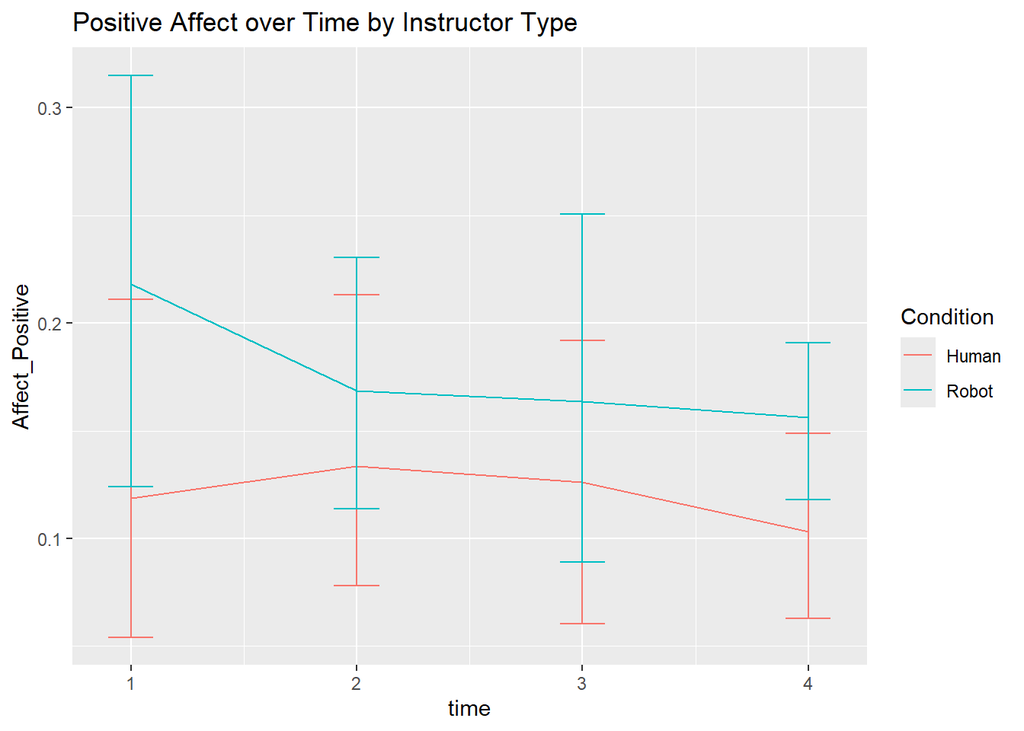

```r
library(glmmTMB)
library(DHARMa)
library(performance)
library(ggplot2)

# Load and prepare your data
df <- read.csv("~/GitHub/Circle-Time-Data-Analyses/CircleTimeData-VBMAPP.csv")

df$Condition <- factor(df$Condition, labels = c("Human", "Robot"))


ggplot(df, aes(x = time, y = Affect_Positive, color = Condition, group = Condition)) +
  stat_summary(fun = mean, geom = "line") +
  stat_summary(fun.data = mean_cl_boot, geom = "errorbar", width = 0.2) +
  labs(title = "Positive Affect over Time by Instructor Type")
```

```r
# Center time if needed
df$time_c <- scale(df$time, center = TRUE, scale = FALSE)

model_novelty <- glmmTMB(
  Affect_Positive ~ Condition * time_c + VBMAPP + (1 | Subject),
  data = df,
  family = beta_family()
)

summary(model_novelty)
```

```
##  Family: beta  ( logit )
## Formula:          Affect_Positive ~ Condition * time_c + VBMAPP + (1 | Subject)
## Data: df
##
##       AIC       BIC    logLik -2*log(L)  df.resid
##    -112.6     -99.5      63.3    -126.6        41
##
## Random effects:
##
## Conditional model:
##  Groups  Name        Variance Std.Dev.
##  Subject (Intercept) 0.1098   0.3314
## Number of obs: 48, groups:  Subject, 6
##
## Dispersion parameter for beta family (): 28.5
##
## Conditional model:
##                       Estimate Std. Error z value Pr(>|z|)
## (Intercept)            2.25516    2.93329   0.769  0.44200
## ConditionRobot         0.43237    0.15053   2.872  0.00408 **
## time_c                -0.02816    0.09604  -0.293  0.76940
## VBMAPP                -2.66528    1.82002  -1.464  0.14308
## ConditionRobot:time_c -0.09323    0.13123  -0.710  0.47744
## ---
## Signif. codes:  0 '***' 0.001 '**' 0.01 '*' 0.05 '.' 0.1 ' ' 1
```

For all Learning Behaviors:

```r
# Load required libraries
library(glmmTMB)
library(DHARMa)
library(performance)
library(ggplot2)

# Load your data
df <- read.csv("~/GitHub/Circle-Time-Data-Analyses/CircleTimeData-VBMAPP.csv")

# Center the time variable
df$time_c <- scale(df$time, center = TRUE, scale = FALSE)

# Apply transformation for all dependent variables (beta regression needs values in (0,1))
epsilon <- 0.0001
vars_to_transform <- c(
  "Affect_Positive", "Affect_Negative",
  "Communication_with_Instructor", "Communication_with_Instructor_Prompted",
  "Communication_with_Therapist", "Communication_with_Indeterminent",
  "Engagement_OnTarget", "Engagement_Therapist", "Engagement_OffTarget",
  "Performance_Positive"
)
for (v in vars_to_transform) {
  df[[v]] <- (df[[v]] * (nrow(df) - 1) + epsilon) / nrow(df)
}

# Function to run model and print summary
run_novelty_model <- function(dep_var) {
  formula <- as.formula(paste0(dep_var, " ~ Condition * time_c + VBMAPP + (1 | Subject)"))
  model <- glmmTMB(formula, data = df, family = beta_family())
  cat("====================================\n")
  cat("Dependent Variable:", dep_var, "\n")
  print(summary(model))
  return(model)
}

# Run models for all learning behaviors
models <- lapply(vars_to_transform, run_novelty_model)
```

```
## ====================================
## Dependent Variable: Affect_Positive
##  Family: beta  ( logit )
## Formula:          Affect_Positive ~ Condition * time_c + VBMAPP + (1 | Subject)
## Data: df
##
##       AIC       BIC    logLik -2*log(L)  df.resid
##    -114.7    -101.6      64.3    -128.7        41
##
## Random effects:
##
## Conditional model:
##  Groups  Name        Variance Std.Dev.
##  Subject (Intercept) 0.109    0.3301
## Number of obs: 48, groups:  Subject, 6
##
## Dispersion parameter for beta family (): 29.2
##
## Conditional model:
##                  Estimate Std. Error z value Pr(>|z|)
## (Intercept)       1.77555    2.93690   0.605   0.5455
## Condition         0.43061    0.15000   2.871   0.0041 **
## time_c            0.06490    0.21104   0.308   0.7584
## VBMAPP           -2.64977    1.81276  -1.462   0.1438
## Condition:time_c -0.09282    0.13074  -0.710   0.4777
## ---
## Signif. codes:  0 '***' 0.001 '**' 0.01 '*' 0.05 '.' 0.1 ' ' 1
## ====================================
## Dependent Variable: Affect_Negative
##  Family: beta  ( logit )
## Formula:          Affect_Negative ~ Condition * time_c + VBMAPP + (1 | Subject)
## Data: df
##
##       AIC       BIC    logLik -2*log(L)  df.resid
##    -656.7    -643.6     335.4    -670.7        41
##
## Random effects:
##
## Conditional model:
##  Groups  Name        Variance  Std.Dev.
```

[output cut: 222 more lines]

```
##  Groups  Name        Variance Std.Dev.
##  Subject (Intercept) 0.2116   0.46
## Number of obs: 48, groups:  Subject, 6
##
## Dispersion parameter for beta family (): 18.8
##
## Conditional model:
##                    Estimate Std. Error z value Pr(>|z|)
## (Intercept)      -12.049873   3.911508  -3.081 0.002066 **
## Condition         -0.372783   0.161501  -2.308 0.020986 *
## time_c             0.009166   0.233606   0.039 0.968700
## VBMAPP             8.672505   2.431820   3.566 0.000362 ***
## Condition:time_c   0.018622   0.144433   0.129 0.897412
## ---
## Signif. codes:  0 '***' 0.001 '**' 0.01 '*' 0.05 '.' 0.1 ' ' 1
```

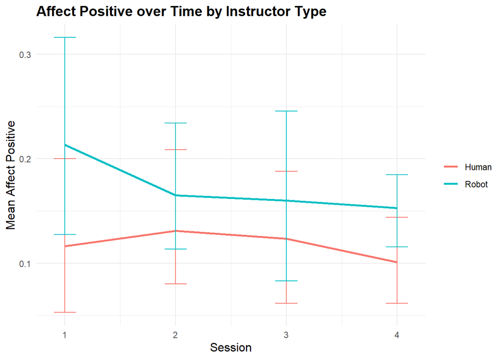

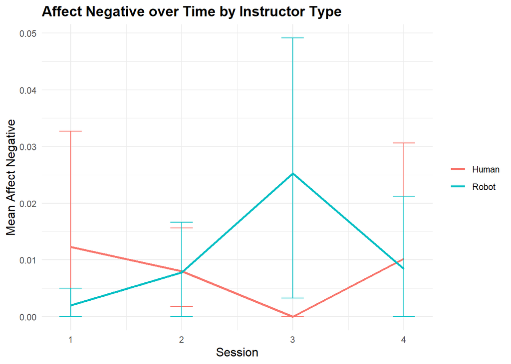

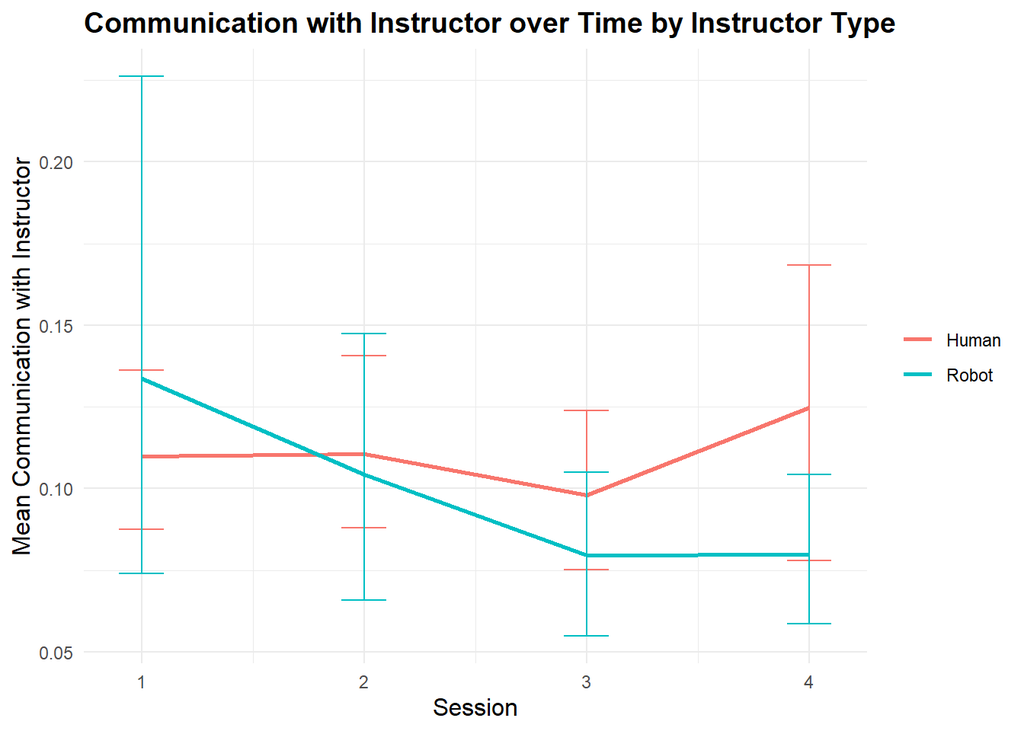

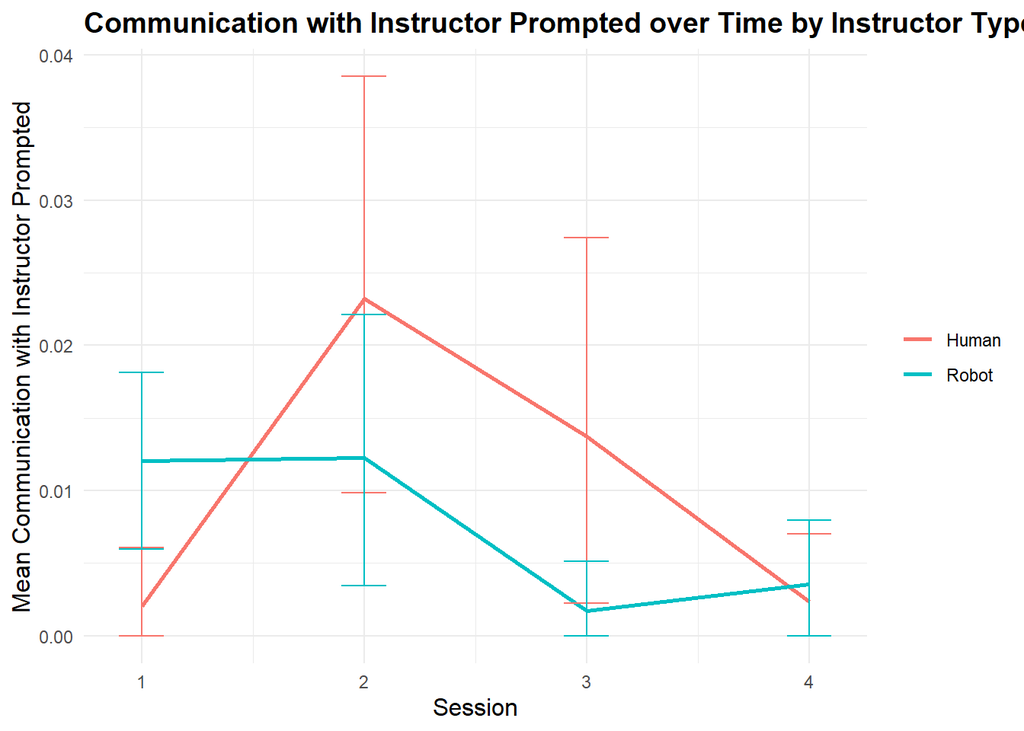

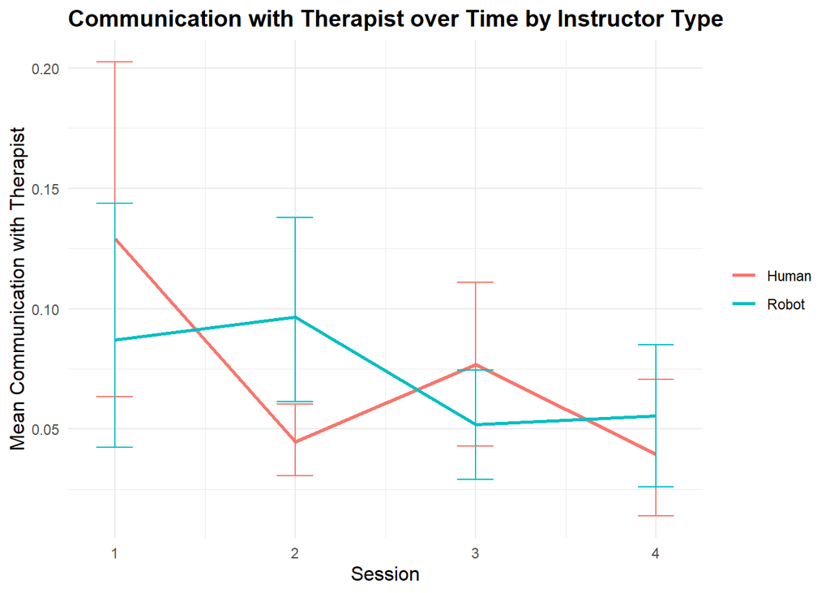

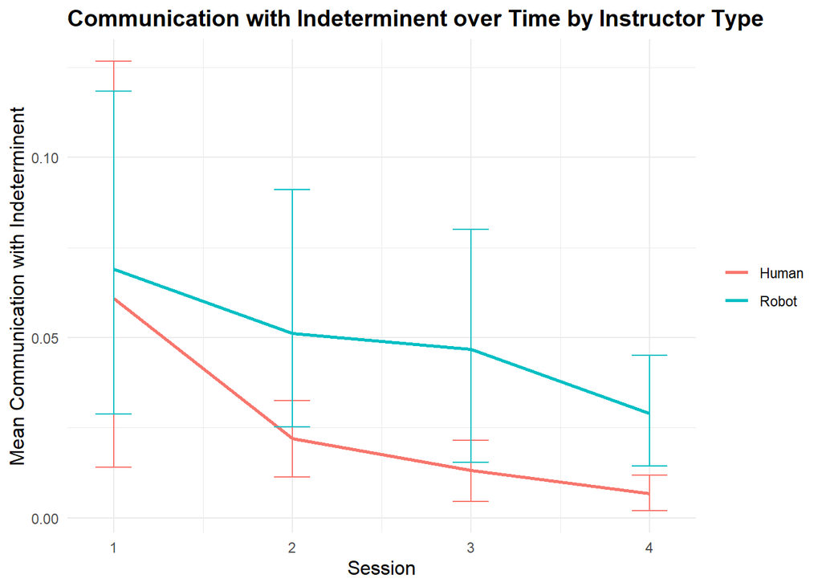

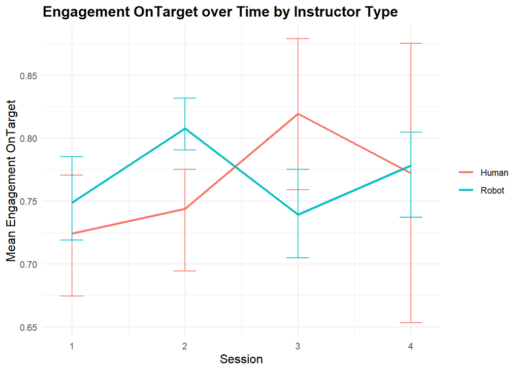

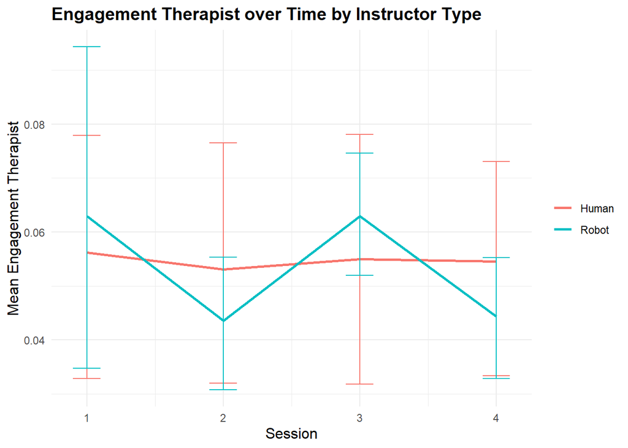

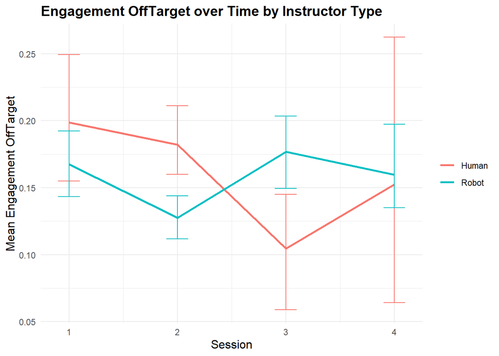

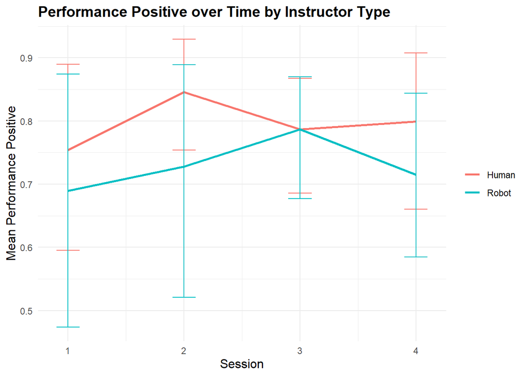

```r
names(models) <- vars_to_transform

library(ggplot2)

# Ensure Condition is a factor with labels
df$Condition <- factor(df$Condition, levels = c(1, 2), labels = c("Human", "Robot"))

# Define your list of learning behavior variables
learning_behaviors <- c(
  "Affect_Positive", "Affect_Negative",
  "Communication_with_Instructor", "Communication_with_Instructor_Prompted",
  "Communication_with_Therapist", "Communication_with_Indeterminent",
  "Engagement_OnTarget", "Engagement_Therapist", "Engagement_OffTarget",
  "Performance_Positive"
)

# Loop through variables and generate plots
for (var in learning_behaviors) {
  p <- ggplot(df, aes_string(x = "time", y = var, color = "Condition", group = "Condition")) +
    stat_summary(fun = mean, geom = "line", size = 1) +
    stat_summary(fun.data = mean_cl_boot, geom = "errorbar", width = 0.2) +
    labs(
      title = paste0(gsub("_", " ", var), " over Time by Instructor Type"),
      x = "Session",
      y = paste("Mean", gsub("_", " ", var))
    ) +
    theme_minimal() +
    theme(
      plot.title = element_text(size = 14, face = "bold"),
      axis.title = element_text(size = 12),
      legend.title = element_blank()
    )

  print(p)  # Display plot in RStudio

  # Optionally save each plot to a file
  ggsave(filename = paste0("plot_", var, ".png"), plot = p, width = 7, height = 5, dpi = 300)
}
```

```r
library(glmmTMB)
library(ggplot2)
library(dplyr)
# Load and center time
df <- read.csv("~/GitHub/Circle-Time-Data-Analyses/CircleTimeData-VBMAPP.csv")
df$time_c <- scale(df$time, center = TRUE, scale = FALSE)

# Variables to analyze
behaviors <- c(
  "Affect_Positive", "Affect_Negative",
  "Communication_with_Instructor", "Communication_with_Instructor_Prompted",
  "Communication_with_Therapist", "Communication_with_Indeterminent",
  "Engagement_OnTarget", "Engagement_Therapist", "Engagement_OffTarget",
  "Performance_Positive"
)

# Apply transformation for beta regression (values in (0,1))
epsilon <- 0.0001
for (v in behaviors) {
  df[[v]] <- (df[[v]] * (nrow(df) - 1) + epsilon) / nrow(df)
}

# Function to model time effect within each condition
run_time_effect_by_condition <- function(dep_var) {
  for (cond in unique(df$Condition)) {
    df_sub <- df[df$Condition == cond, ]
    model <- glmmTMB(
      as.formula(paste0(dep_var, " ~ time_c + VBMAPP + (1 | Subject)")),
      data = df_sub,
      family = beta_family()
    )

    cat("====================================\n")
    cat("Behavior:", dep_var, "| Condition:", cond, "\n")
    print(summary(model)$coefficients$cond["time_c", ])
  }
}

# Run the loop
lapply(behaviors, run_time_effect_by_condition)
```

```
## ====================================
## Behavior: Affect_Positive | Condition: 1
##    Estimate  Std. Error     z value    Pr(>|z|)
## -0.05970746  0.06604392 -0.90405685  0.36596526
## ====================================
## Behavior: Affect_Positive | Condition: 2
##    Estimate  Std. Error     z value    Pr(>|z|)
## -0.12777941  0.07802584 -1.63765495  0.10149369
## ====================================
## Behavior: Affect_Negative | Condition: 1
##   Estimate Std. Error    z value   Pr(>|z|)
## -0.1219848  0.1828694 -0.6670594  0.5047342
## ====================================
## Behavior: Affect_Negative | Condition: 2
##   Estimate Std. Error    z value   Pr(>|z|)
##  0.0545930  0.1721961  0.3170396  0.7512135
## ====================================
## Behavior: Communication_with_Instructor | Condition: 1
##     Estimate   Std. Error      z value     Pr(>|z|)
## -0.001486943  0.073182235 -0.020318361  0.983789409
## ====================================
## Behavior: Communication_with_Instructor | Condition: 2
##    Estimate  Std. Error     z value    Pr(>|z|)
## -0.18748566  0.08819411 -2.12582979  0.03351743
## ====================================
## Behavior: Communication_with_Instructor_Prompted | Condition: 1
##    Estimate  Std. Error     z value    Pr(>|z|)
## -0.02790947  0.15630052 -0.17856286  0.85828096
## ====================================
## Behavior: Communication_with_Instructor_Prompted | Condition: 2
##    Estimate  Std. Error     z value    Pr(>|z|)
## -0.42108847  0.18456072 -2.28157150  0.02251465
## ====================================
## Behavior: Communication_with_Therapist | Condition: 1
##      Estimate    Std. Error       z value      Pr(>|z|)
## -5.617306e-01  1.369691e-01 -4.101149e+00  4.111033e-05
## ====================================
## Behavior: Communication_with_Therapist | Condition: 2
##    Estimate  Std. Error     z value    Pr(>|z|)
## -0.32307454  0.14379865 -2.24671473  0.02465826
```

[output cut: 25 more lines]

```
## Behavior: Engagement_OffTarget | Condition: 1
##    Estimate  Std. Error     z value    Pr(>|z|)
## -0.25173660  0.11417898 -2.20475423  0.02747135
## ====================================
## Behavior: Engagement_OffTarget | Condition: 2
##   Estimate Std. Error    z value   Pr(>|z|)
## 0.01539456 0.04985095 0.30881175 0.75746473
## ====================================
## Behavior: Performance_Positive | Condition: 1
##    Estimate  Std. Error     z value    Pr(>|z|)
## 0.007102597 0.091254499 0.077832842 0.937961021
## ====================================
## Behavior: Performance_Positive | Condition: 2
##   Estimate Std. Error    z value   Pr(>|z|)
## 0.03860976 0.11460455 0.33689551 0.73619567
```